# Chapter 4

Sam and Nelson

16/10/2019

```r
#load ALL of the libraries you will need first
library(tidyverse)
library(xkcd)
library(showtext)
library(sysfonts)
library(Hiiragi2013)
library(mouse4302.db)
library(reshape2)
library(Hmisc)
library(ggbeeswarm)
library(modes)
library(RColorBrewer)
library(ggthemes)
library(magrittr)
library(plotly)
library(rgl)
library(pheatmap)
library(colorspace)
library(grid)
library(ggbio)
library(GenomicRanges)
library(flexmix)
library(mclust)
library(mixtools)
library(mosaics)
library(mosaicsExample)
library(here)
library(HistData)
library(bootstrap)
library(vcd)
```

**Table of contents**

[1] Where might you see mixture data?  
[2] What is mixture data?  
[3] Chapter Goals  
[4] Finite Mixtures  
[5] The Expectation-Maximization (EM) Algorithm  
[6] Zero inflated data  
[7] More than two components  
[8] Empirical distributions and the nonparametric bootstrap  
[9] Why is this bootstrapping method called nonparametric?  
[10] Infinite Mixtures  
[11] Infinite mixture of normals  
[12] Asymmetric Laplace  
[13] Infinite mixtures of poisson variables: the gamma-poisson distribution  
[14] Choosing a data transformation based on a mixture model of your data: variance stabilizing transformations  
[15] Exercises

**Where might you see mixture data?**<sup>Return</sup>

- Flow cytometry
- RNA-seq
- ChIP-Seq
- Microbiome

What do these types of data have in common? Can you think of any other types of data that might be considered a mixture?

**What is mixture data?**<sup>Return</sup>

Heterogeneity (diversity) is a problem with biological data analysis. In other words, biological data often do not follow a unimodal distribution. This requires us to look at the data as a mixture of a few (or many) components. We call this type of data *mixture data*.

Think of combining 2 distributions

- It can be a mix of different distributions (Normal+Binomial) or mixture of the same distribution but with different parameters
- Mixture models can be used to find exptected values, maximum likelihood parameters estimate, and others

In some mixture data sets we are able to determine if the number of components is small and less than the number of our observations - this is called *finite mixture data*.  
In other mixture data sets, the number of components is equal to (or greater than) our number of observerations - this type of mixture data is called *infinite mixture data*.

**Chapter Goals**<sup>Return</sup>

- Generate mixture data from two normal populations
- Use expectation-maximization (EM) to determine the number of mixtures in your data
- Learn how analyze mixture data with many zeros (such as Chip-seq data) using zero-inflation
- Learn about the empiral cumulative distribition
- Learn what bootstrapping is and how to use it
- Learn about the gamma-Poisson distribution (looking at you RNA-seq-ers)
- Learn how to choose a data transformation based on a mixture model of your data

**Finite Mixtures**<sup>Return</sup>

Let’s model a finite mixture model (based on the normal distribution) with two equal components based on the outcomes of flipping a fair coin.

The standard normal distrubution has the following inputs:

- n (number of observations)
- mu - population mean
- standard deviation (sd)

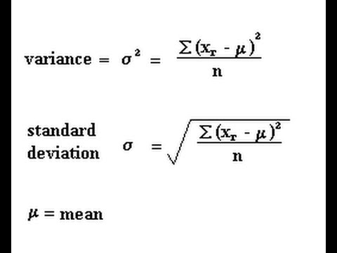

In plain english, our code will do the following:

- Create a variable coinFlips by “flipping” a coin 10000 times where >0.5 is equal to TRUE (heads) and <=0.5 is equal to FALSE (tails)
- We will create a function (oneFlip) to generate 2 normal distributions:
  - When the coin is TRUE (heads), a random normal distrubtion variable with mean 1 and standard deviation 0.5 will be generated
  - When the coin is FALSE (tails), a random normal distrubtion variable with mean 3 and standard deviation 0.5 will be generated
- We will use vapply to apply oneFlip to coinFlips to generate our 2 component mixture model

```r
#set seed so we always get the same outcome
set.seed(1234)
#coinflips flips a fair coin 10000 times - split this into logical(TRUE/FALSE) by 0.5 due to fair coin (Heads/tails)
coinflips = (runif(10000) > 0.5)
#table of true/false (heads/tail) outcome from coinflips
table(coinflips)
```

```
## coinflips
## FALSE  TRUE
##  4990  5010
```

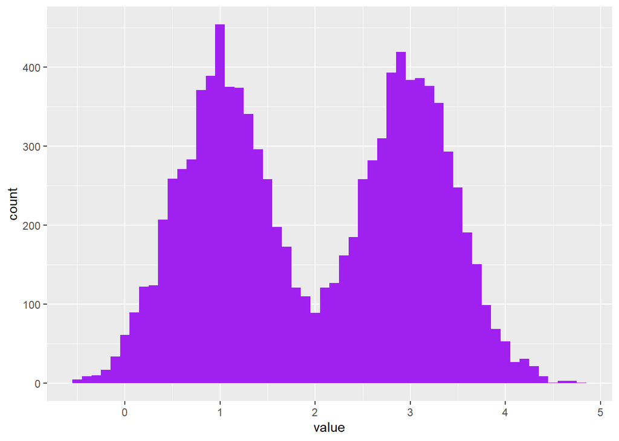

```r
#one flip generates 2 normal distributions, one from a distribution with mean=1, var=0.25 (sd=0.5) [distribution1], and one from a distribution with mean=3 and var=0.25 [distribution2]
  # Think of TRUE=1 & FALSE=0
  # If the coinflip is TRUE(1) then this function will evaluate using distribution1
    # If FALSE, then distribution2
oneFlip = function(fl, mean1 = 1, mean2 = 3, sd1 = 0.5, sd2 = 0.5) {
  if (fl) {
   rnorm(1, mean1, sd1)
  } else {
   rnorm(1, mean2, sd2)
  }
}

#Fairmix is generated by applying the oneflip function to all coinflips in the vector
  #if coinflips = true, run if statement (1st distribution), if false run else (2nd distribution)
fairmix = vapply(coinflips, oneFlip, numeric(1))
ggplot(tibble(value = fairmix), aes(x = value)) +
     geom_histogram(fill = "purple", binwidth = 0.1)
```

If you thought vapply() was the best thing since for loops, you’ll be excited to learn there’s an even easier way to accomplish the above using rnorm(), by setting the “x=” argument to the length of the `coinflips` vector and the ifelse command.

*WATCH OUT*: The authors suddenly started using variance instead of standard deviation for some reason that is unknown to us. The graph outputs will vary because standard deviation gives more of a spread from the mean.

- For our example, we will show that you can generate the same graphs without using vapply(), as long as we consistently use standard deviation or varience in both methods.

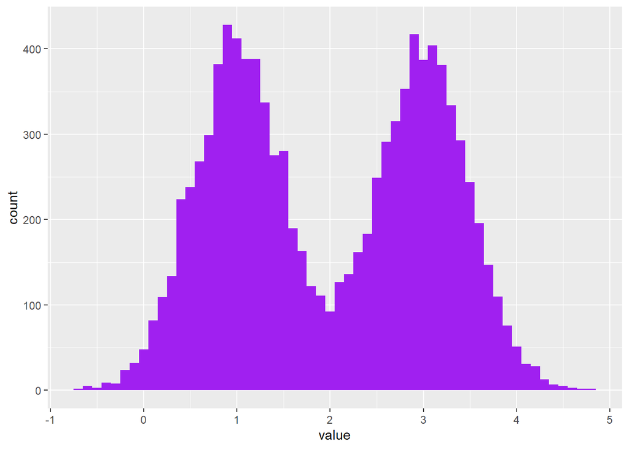

```r
#set seed so we always get the same outcome
set.seed(1234)
#set your population means to 1 and 3
means = c(1, 3)
#set variance to 0.5 (var=0.25)
sds = c(0.5, 0.5)

#generate random normal distribution with length (n) equal to the length of coinflips
  #if coinflips is TRUE, mean =1 and var =0.25
  #if coinflips is FALSE, mean=3 and var=0.25
values = rnorm(length(coinflips),
          mean = ifelse(coinflips, means[1], means[2]),
          sd   = ifelse(coinflips, sds[1],   sds[2]))

ggplot(tibble(value = values), aes(x = value)) +
     geom_histogram(fill = "purple", binwidth = 0.1)
```

Now we can use are more succinct code to ask the question: What would happen if you flipped a coin 1 million times (and also made a histogram with 500 bins to show the outcome)?

- **NOTE** - We have to store the outputs of the simulated distributions as a dataframe, or in this case tibble() because this is what ggplot requires

```r
#set the seed for sameness
set.seed(1234)
#flip that coin 1000000 times
coinflips_1000000 = (runif(1000000) > 0.5)
#table of true/false (heads/tail) outcome from coinflips
table(coinflips_1000000)
```

```
## coinflips_1000000
##  FALSE   TRUE
## 500308 499692
```

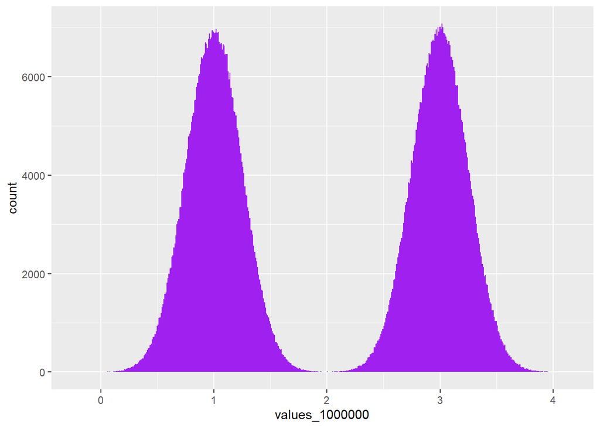

```r
#I always reinitialize vectors and variables in case I previously messed them up
means = c(1, 3)
sds = c(0.25, 0.25)
#rerun
values_1000000 = rnorm(length(coinflips_1000000),
          mean = ifelse(coinflips_1000000, means[1], means[2]),
          sd   = ifelse(coinflips_1000000, sds[1],   sds[2]))

#plot it to compare
ggplot(tibble(values_1000000), aes(x = values_1000000)) +
  geom_histogram(fill = "purple", bins = 500)
```

But how does the distribution density of our 1000000 coin flips from the population with mean=1 (TRUE/Heads flip) look like if we converted the y-axis to a proportion of counts?

- **NOTE** - a single NORMAL distribution in a mixture model is denoted Φ(X) where phi is the density of a normal distribution N(mu,var)

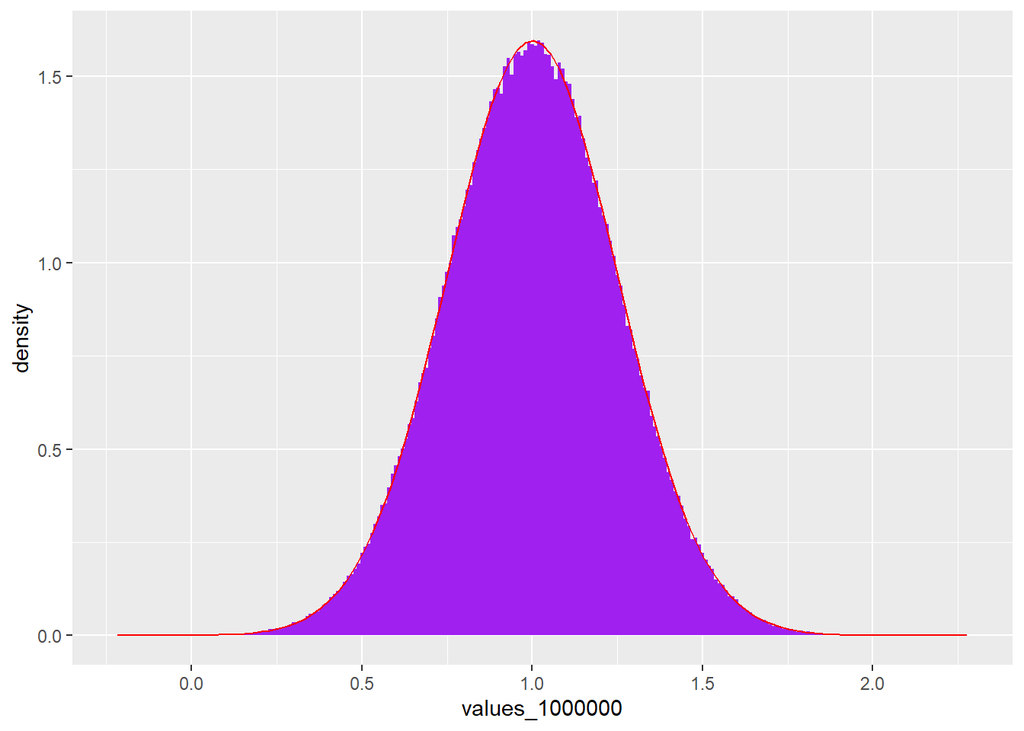

```r
ggplot(dplyr::filter(tibble(values_1000000), coinflips_1000000), aes(x = values_1000000)) +
   geom_histogram(aes(y = ..density..), fill = "purple",
                  binwidth = 0.01) +
   stat_function(fun = dnorm,
          args = list(mean = means[1], sd = sds[1]), color = "red")
```

It looks pretty darn close to the normal distribution with y-axis of counts.

Thus, we can write a general formula for density of any mixture model by suming the densities of individual normal distributions (proportionately).

> $$\begin{equation}
> f(x)=\frac{1}{2}\phi_1(x)+\frac{1}{2}\phi_2(x)
> \tag{4.1}
> \end{equation}$$

Now, what if we wanted to just visualize a theoretical density of the mixture without generating Heads/Tails and calculating proportion results from a coinflip?

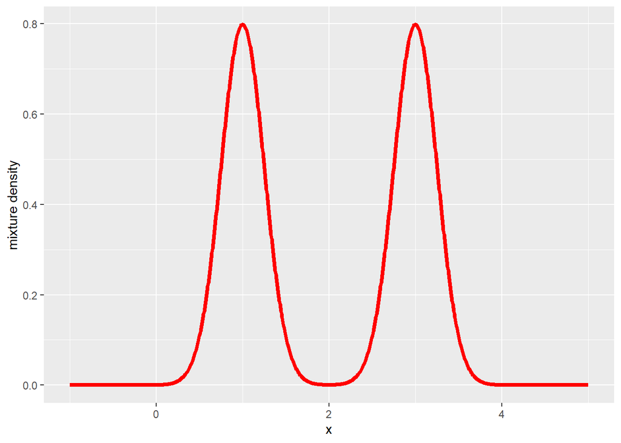

```r
# Note - seq(from -1 to 5 with 1000 variables) replaces coinflips
  # 0.5 is probability of heads/tails because of a fair coin - this gives us a distribution where probabilities sum to 1
fairtheory = tibble(
  x = seq(-1, 5, length.out = 1000),
  f = 0.5 * dnorm(x, mean = means[1], sd = sds[1]) +
      0.5 * dnorm(x, mean = means[2], sd = sds[2]))
ggplot(fairtheory, aes(x = x, y = f)) +
  geom_line(color = "red", size = 1.5) + ylab("mixture density")
```

Assume you didn’t see the code below and only the figure. Can you guess the means of the two sample mixture below? Each component has same variance.

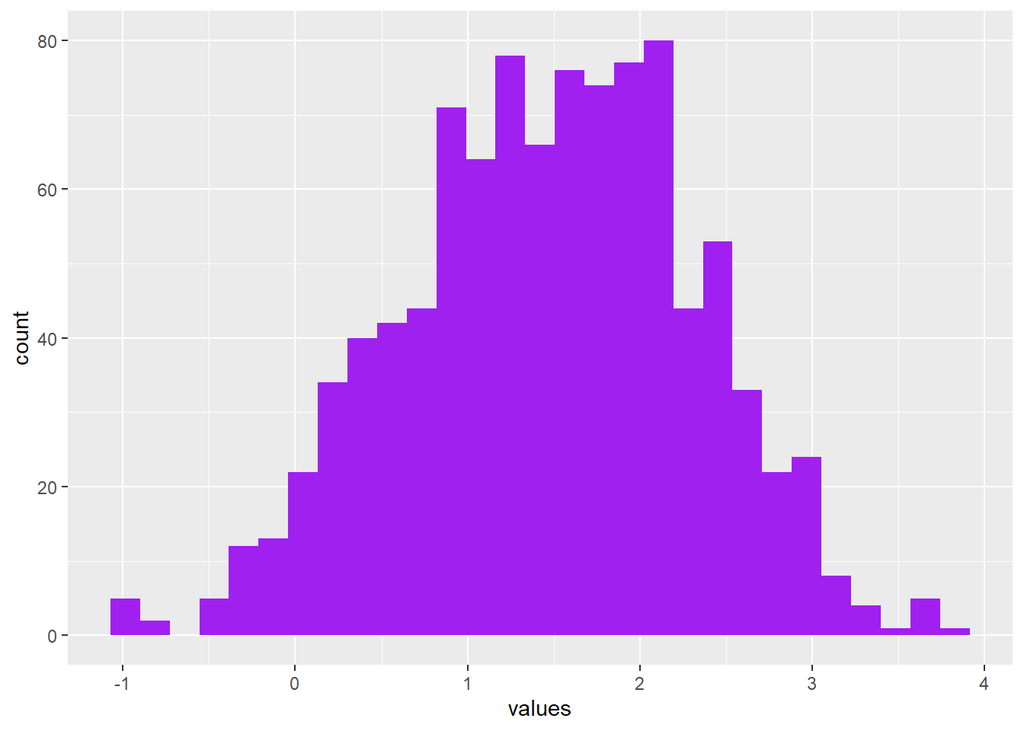

```r
set.seed(1234)
mystery = tibble(
  #generate 1000 true/false statements
  coinflips = (runif(1e3) > 0.5),
  #generate
  values = rnorm(length(coinflips),
                #mean at 1 if true and 2 if false
               mean = ifelse(coinflips, 1, 2),
               #variance =0.5. std dev = ~0.7
               sd   = ifelse(coinflips, sqrt(.5), sqrt(.5))))
#generate a 30 number sequence based on the min value generated from mystery to the max num generated by mystery
br2 = with(mystery, seq(min(values), max(values), length.out = 30))
#plot
ggplot(mystery, aes(x = values)) +
geom_histogram(fill = "purple", breaks = br2)
```

Probably not, finite mixture models be hard to distinguish if similar mixture distributions have similar means (in this case normal distribution 1 mu=1, normal distribution 2 mu=2)

Now that we know how the data was generated, we can identify the two components of the mixture.

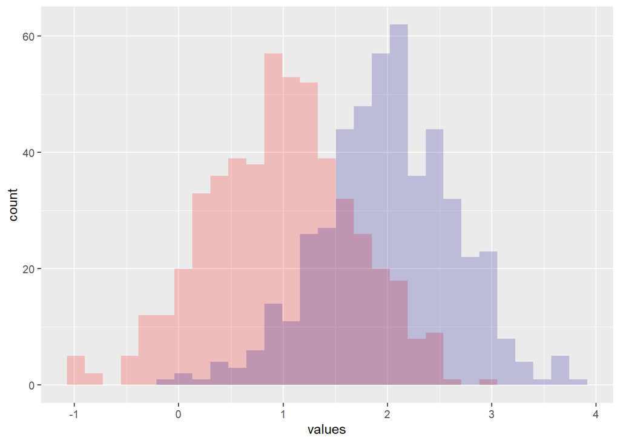

```r
ggplot(mystery, aes(x = values)) +
  #histogram for coinflips=true
  geom_histogram(data = dplyr::filter(mystery, coinflips),
     fill = "red", alpha = 0.2, breaks = br2) +
  #histogram for coinflips=false
  geom_histogram(data = dplyr::filter(mystery, !coinflips),
     fill = "darkblue", alpha = 0.2, breaks = br2)
```

This doesn’t look quite like our original two mixture model though. This is because in that figure the overlapping bars (purple in this figure) are plotted additively (not on top of each other).

Here is another method the author used to show overlap of finite mixtures

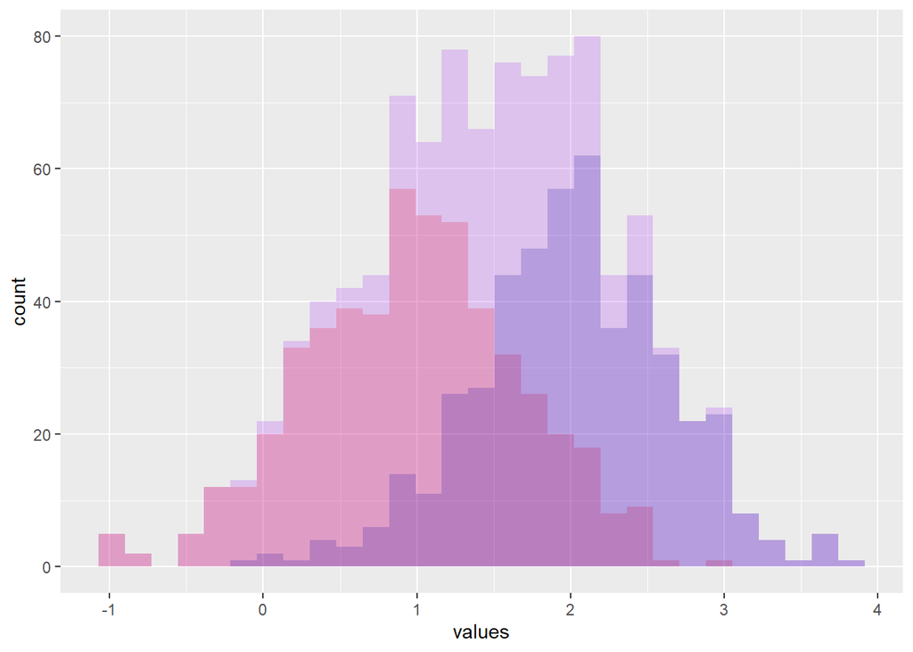

```r
ggplot(mystery, aes(x = values, fill = coinflips)) +
  #plot positive coin flips red
  geom_histogram(data = dplyr::filter(mystery, coinflips),
     fill = "red", alpha = 0.2, breaks = br2) +
  #plot negative coinflips blue
  geom_histogram(data = dplyr::filter(mystery, !coinflips),
     fill = "darkblue", alpha = 0.2, breaks = br2) +
  #plot the first figure we were guessing (ie. all coinflips)
  geom_histogram(fill = "purple", breaks = br2, alpha = 0.2)
```

Both methods of showing overlapping distributions utilize `coinflips` column of TRUE/FALSE to separate components/groups by colour

- In real data, these hidden groupings would be missing information.

**The Expectation-Maximization (EM) Algorithm**<sup>Return</sup>

The EM algorithm is used to infer the value of hidden components.  
The EM algorithm alternates between:

- Pretending to know the probability that each observation belongs to a component (and estimating the distribution paramaters of these components)
- Pretending to know the distribution values of each component (and re-estimating the probability that each observation belongs to a given component)

A simple example:  
A variable Y is measured on a series of objects that come from two groups (but we do not know which group each object belongs to).  
- Start by augmenting the data with a latent (unobserved/hidden) variable, called U.  
- Use the maximum likelihood approach to find the values of U and the unknown parameters of underlying densities.  
- We will use the bivariate distribution because we are looking at the distribution of “couples” (Y,U)

- Value of θ maximizing E*(expection) found in *maximization step*
  - Iterations through E & M repeated until E* increases are small -> indicates plateauing likelihood = reaching local max
    - Iteration path **depends on starting point** but always end up at the same end point (assuming 1 end point)
    - Good practice to repeat procedure several times from different start points to see if same answer received
  - (Better defined by breaking up the EM algorithm in excercise 4.1)

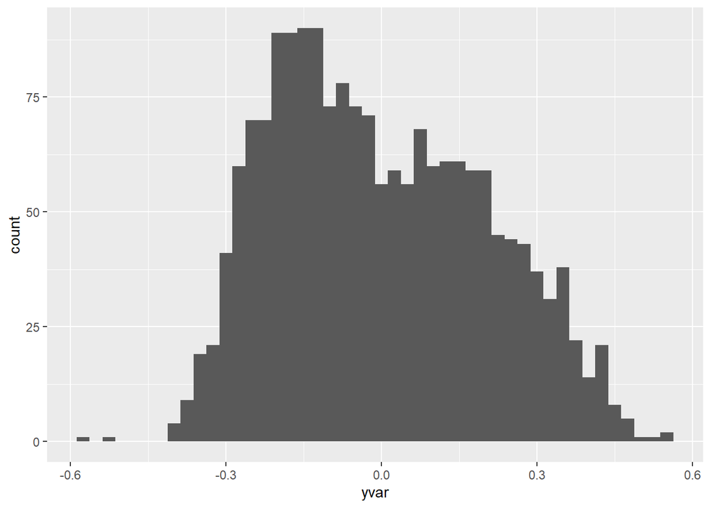

```r
#load in data
yvar = readRDS(here("bookStuff", "data", "Myst.rds"))$yvar
#view data in histogram
ggplot(tibble(yvar), aes(x = yvar)) + geom_histogram(binwidth=0.025)
```

```r
#explore the structure of the data
str(yvar)
```

```
##  num [1:1800] 0.3038 0.0596 -0.0204 0.1849 0.2842 ...
```

```r
#we want to model the data in yvar as a mixture of 2 normal #distributions with components A and B

#create a random uniform distribution equal to the length of yvar (1000) with each entry equal to the probability of that data point belonging to component
pA = runif(length(yvar))
#make another numeric vector with probabilities of belonging to pB
pB = 1 - pA

#counter for iterations of the EM algorithm
iter = 0
#stores the current log-likelihood
loglik = -Inf
#stores the change in the log-likelihood from the previous iteration to the current one
delta = +Inf
tolerance = 1e-3
miniter = 50; maxiter = 1000

#run this loop until delta converges upon tolerance
#continuing running while inter is less than or equal to 1000 or less than 50
while((delta > tolerance) && (iter <= maxiter) || (iter < miniter)) {
  #THIS IS THE E-STEP
  #lamda is the mixture fraction
  lambda = mean(pA)
  #set mean for component A
  muA = weighted.mean(yvar, pA)
  #set mean for component B
  muB = weighted.mean(yvar, pB)
  #calculate standard deviation for component A
  sdA = sqrt(weighted.mean((yvar - muA)^2, pA))
  #calculate standard deviation for component B
  sdB = sqrt(weighted.mean((yvar - muB)^2, pB))

  #THIS IS THE M-STEP
  #the density of group A
  phiA = dnorm(yvar, mean = muA, sd = sdA)
  #the density of group B
  phiB = dnorm(yvar, mean = muB, sd = sdB)
  #formula for density fraction made up by A
  pA   = lambda * phiA
  #formula for density fraction made up by B
  pB   = (1 - lambda) * phiB
  #formula for density of mixture
  ptot = pA + pB

  pA   = pA / ptot
  pB   = pB / ptot

  loglikOld = loglik
  loglik = sum(log(pA))
  delta = abs(loglikOld - loglik)
  iter = iter + 1
}
param = tibble(group = c("A","B"), mean = c(muA,muB), sd = c(sdA,sdB))
param
```

```
## # A tibble: 2 x 3
##   group   mean     sd
##   <chr>  <dbl>  <dbl>
## 1 A      0.147 0.150
## 2 B     -0.169 0.0983
```

```r
iter
```

```
## [1] 377
```

Question: Which lines correspond to the E-step, which to the M-step?

The basic outline of the EM procedure is as follows:  
(found on https://www.statisticshowto.datasciencecentral.com/em-algorithm-expectation-maximization/)

1. An initial guess is made for the model’s parameters and a probability distribution is created. This is sometimes called the “E-Step” for the “Expected” distribution.
2. Newly observed data is fed into the model.
3. The probability distribution from the E-step is tweaked to include the new data. This is sometimes called the “M-step.”
4. Steps 2 through 4 are repeated until stability (i.e. a distribution that doesn’t change from the E-step to the M-step) is reached.

The E-step includes the lines where we set the probability that each data point belongs to component A or B as well as the lines where we calculate lamda, muA, muB, sdA, and sdB. This step incorporates pA and pB which were revised in the M-Step.

> lambda = mean(pA)  
> muA = weighted.mean(yvar, pA)  
> muB = weighted.mean(yvar, pB) sdA = sqrt(weighted.mean((yvar - muA)^2, pA))  
> sdB = sqrt(weighted.mean((yvar - muB)^2, pB))

The maximum-likelihood estimation (MLE) is used to estimate the means for each group based on group density and mixture fraction and can be split into 2 equations and solved separately. The M-step includes:

> phiA = dnorm(yvar, mean = muA, sd = sdA)  
> phiB = dnorm(yvar, mean = muB, sd = sdB)  
> pA = lambda * phiA  
> pB = (1 - lambda) * phiB  
> ptot = pA + pB

> pA = pA / ptot  
> pB = pB / ptot
1. What does the M-step do, what does the E-step do?

The M-step takes the “unknown” parameters generated from the E step and uses them to modify/update the “known” parameters (probability of belong to group A or B).

The E-step takes our known parameters (probability of belong to group A or B) and uses these parameters to generate the missing (mean, standard deviation) for our function.

2. What is the role of the algorithm arguments tolerance, miniter and maxiter?

Tolerance represents the minimum difference between log-likelihood estimates needed to loop. Miniter is the minimum number of times that we must interate between the E and M steps. Maxiter is the maximum number of times we are allowed to interate between our E and M steps.

Class question: How do you think the authors determined tolerance? Is it always the same? Does it change? Is it related to a p-value? Thoughts?

3. Why do we need to compute loglik?

We need to compute loglik so that we can observe how likely we our converging between our “guessed” model of data and the best fit of our parameters. When the difference between loglik and loglikOld is very small, this suggests that we have reached our maximum and have found our best model for the data.

- The `loglik` variable stores the current log-likelihood value of mixture model which estimates that the current parameters (lambda, mu, sd) are maximized to represent data
  - the `loglik` value updates per iteration based upon sum(log(probabilities for component A)) which is changed per E-step iteration
  - This allows us to calculate delta, which is the difference between the previous iteration loglikelihood vs current itertion loglikelihood
    - Once delta becomes lower than the tolerance (ie) Previous iteration loglikelihood < current loglikelihood) that’s an assumptuion that the E & M-step converges and there is no benefit for further estimation
5. Compare the results of what we are doing to the output of the normalmixEM function from the mixtools package:

```
mixtoolsQ <- normalmixEM(x=yvar, k=2, maxit=1000)
paste(mixtoolsQ$mu, "these are the maximized mean estimates")
paste(mixtoolsQ$sigma, "these are the maximized lambda estimates")
paste(mixtoolsQ$loglik, "this is the MLE")
```

```r
mclusttest <- Mclust(yvar, G=2)
summary(mclusttest)
```

```
## ----------------------------------------------------
## Gaussian finite mixture model fitted by EM algorithm
## ----------------------------------------------------
##
## Mclust V (univariate, unequal variance) model with 2 components:
##
##  log-likelihood    n df      BIC      ICL
##        417.1554 1800  5 796.8332 383.0647
##
## Clustering table:
##   1   2
## 921 879
```

```r
mclusttest$parameters
```

```
## $pro
## [1] 0.4891959 0.5108041
##
## $mean
##          1          2
## -0.1663725  0.1528810
##
## $variance
## $variance$modelName
## [1] "V"
##
## $variance$d
## [1] 1
##
## $variance$G
## [1] 2
##
## $variance$sigmasq
## [1] 0.009966078 0.021585106
##
## $variance$scale
## [1] 0.009966078 0.021585106
```

These paramters are close to the parameters of the function we just generated.

How would this work if applied to two unfair coins with p1=0.125(Coin1), p2=0.25(Coin2), probability of of picking coin 1 equal to π and probability of picking coin 2 equal to 1-π when we toss the coin twice and record the number of heads K?

- Probability of tossing coin1 in toss 1 -> π=1/8
- Probability of tossing coin2 in toss 2 -> π=1/4

```r
#simulate 100 instances of this procedure and compute the contigency table

probHead = c(0.125, 0.25)
set.seed(1234)
#compute 2 contingency tables, one for pi=1/8 and one for pi=1/4
for (pi in c(1/8, 1/4)) {
  whCoin = sample(2, 100, replace = TRUE, prob = c(pi, 1-pi))
  K = rbinom(length(whCoin), size = 2, prob = probHead[whCoin])
  print(table(K))
}
```

```
## K
##  0  1  2
## 55 33 12
## K
##  0  1  2
## 60 29 11
```

These contingecy tables look similar. Thus, it would be hard to identify the distribution parameters based on this data. This illustrates the issue **indentifiability** -> same observed values can have several explainantions of values (p1, p2, π). This occurs when there are too many degrees of freedom in the parameters (df = n-1)

> Another way to look at degrees of freedom is that they are the number of values that are free to vary in a data set. What does “free to vary” mean? Here’s an example using the mean (average):  
> Q. Pick a set of numbers that have a mean (average) of 10.  
> A. Some sets of numbers you might pick: 9, 10, 11 or 8, 10, 12 or 5, 10, 15. Once you have chosen the first two numbers in the set, the third is fixed. In other words, you can’t choose the third item in the set. The only numbers that are free to vary are the first two. You can pick 9 + 10 or 5 + 15, but once you’ve made that decision you must choose a particular number that will give you the mean you are looking for. So degrees of freedom for a set of three numbers is TWO.  
> For example: if you wanted to find a confidence interval for a sample, degrees of freedom is n – 1. “N’ can also be the number of classes or categories.

The follow question states means are unknown but then procceeds to provide mean of -0.5 & 1.5. Does y indicate estimated means, and if so where does mus come from?

Let’s look at another example of a mixture of two normals with mean parameters unknown and standard deviation equal to 1 (μ1=?,μ2=?,σ1=σ2=1).

```r
#lets generate that model using R
#the labels are "U"
mus = c(-0.5, 1.5)
#randomly sample 1 or 2, 100 times, with replacement
set.seed(1234)
u = sample(2, 100, replace = TRUE)
#create a random normal distribution of 100 numbers with mean equal to -0.5(1) or 1.5(2)
y = rnorm(length(u), mean = mus[u])
#create tibble duy with mus and means
duy = tibble(u, y)
head(duy)
```

```
## # A tibble: 6 x 2
##       u      y
##   <int>  <dbl>
## 1     2 -0.306
## 2     2  0.918
## 3     2  0.391
## 4     2  0.485
## 5     1 -0.662
## 6     2  2.06
```

Notice in previous the `coinflips` example, the results of the vector are logical (TRUE/FALSE). Here, since the means are unknown the values are 1 or 2.

Since we know the labels “u” (1 or 2), we can estimate the means by using seperate ML equations for each group.

- If we know the labels (u), we can estimate means using separate MLEs for each group.
  - The overall MLE obtained by maximizing the following equation. Or by its log.
    - Maximization can be split into 2 independent pieces & solved (ex) 2 different MLE equations to solve)

$$\begin{equation}
f(y, u \,|\, \theta) =
\prod_{\{i:\,u_i=1\}} \phi_1(y_i)
\prod_{\{i:\,u_i=2\}} \phi_2(y_i),
\tag{4.3}
\end{equation}$$

```r
#group the tibble `duy` at "u" column (group by 1's or 2's), then summarize the mean of the "y" column within group
duy %>% group_by(u) %>% summarise(mean(y))
```

```
## # A tibble: 2 x 2
##       u `mean(y)`
##   <int>     <dbl>
## 1     1    -0.479
## 2     2     1.62
```

Suppose we knew the mixing proportion was λ=1/2, so that we can calculate the so that the density by suming the denisity of the mixture proportionately. What prevents us from solving for the MLE explicitly here?

- **NOTE** - think back to this equation

$$\begin{equation}
f(x)=\frac{1}{2}\phi_1(x)+\frac{1}{2}\phi_2(x)
\tag{4.1}
\end{equation}$$

- Which can also be viewed as, where
  - Φ(x) = N(mu, var)
  - λ = mixture weight for an individual distribution within a mixture model

$$\begin{equation}
f(x)=λ\phi_1(x)+λ\phi_2(x)
\end{equation}$$

- To estimate a mixture model, we need weighted MLE - weights given by posterior label probabilities
- repetition depends on parameters estimated
- We wouldn’t know labels “u” or mixture proportion “λ” in real data
  - Need to have an inital guess for labels (u)
  - Need to estimate parameters
  - Need iterations through EM algorithm - this updates “best guess” for group labels & parameters
    - eventually, this effect plateaus into no improvement per cycling (Indicated by the marginal likelihood)
      - **Marginal likelihood** for observed y = sum overall possible values of (u) of the densities at (y,u)
- Can replace the “hard labels” for u observations (groups 1 & 2)
  - via group membership probabilities summing to 1
  - Probability p(u,x|θ) is the weight/participation of observed x in likelihood function
    - AKA soft averaging - make weighted averages where probabilities of each point is used as weight. Thus, we don’t have to decide if the point belongs to one group or another

  $$\begin{equation*}
  \text{marglike}(\theta;y)=f(y\,|\,\theta)=\sum_u f(y,u\,|\,\theta) \,\text{d}u.
  \end{equation*}$$
- Each iteration (present values marked *) includes the current best guess for unknown parameters (ex) μ1*, μ2*)
  - This is combined into θ* =(μ1*, μ2*, λ*)
    - Used to compute expection function E*(θ) (expectation = average/integrate over all possible values of u)

$$\begin{equation*}
E^*(\theta)=E_{\theta^*,Y}[\log p(u,y\,|\,\theta^*)]=\sum_u p(u\,|\,y ,\theta^*)
\log p(u,y\,|\,\theta^*),
\end{equation*}$$

- Value of θ maximizing E* found in *maximization step*
  - Iterations through E & M repeated until E* increases are small -> indicates plateauing likelihood = reaching local max
    - Iteration path *depends on starting point* but always end up at the same end point (assuming 1 end point)
    - Good practice to repeat procedure several times from different start points to see if same answer received

Several R packages provide EM implementations, including `mclust`, `EMcluster` and `EMMIXskew`. Choose one and run the EM function several times with different starting values. Then use the function normalmixEM from the mixtools package to compare the outputs.

```r
EMtest <- Mclust(duy$y, G=2) #where G is the number of components
EMtest$n
EMtest$df
EMtest$BIC
EMtest$classification
head(duy$u,20)

mixtools <- normalmixEM(duy$y, k=2)
paste(mixtools$lambda, "when lambda")
paste(mixtools$mu, "when mean")
paste(mixtools$sigma, "when sd")
paste(mixtools$loglik, "when loglikelihood")
```

The EM algorithm is very informative:

- Shows that hard questions wih many unknowns can be solved via alternating by solving simpler problems
  - Eventually finds estimates of hidden variables
- Example of **soft averaging** (don’t need to decide if observation belongs to group 1 or 2 - observation can join multiple groups by using probability membership as weights) -> better estimates of parameters
- Can use this method for general case of model averaging
  - Consider several models at once to see which is better fit for data -> combine them into a weighted model
  - Weights provided by log likelihoods of each model

**Zero inflated data** <sup>Return</sup>

//I dislike that this section doesn’t actually go over how to deal with zero inflated data. They just point you to other packages.

Biological data often comes in counts. For example, how many reads from each bacterial species were observed in a given RNA-seq sample?

Such data can often be seen as a mixture of two scenarios:

- If the species is not present, the count is zero.
- If the species is present, the number of individuals we observe varies, with a random sampling distribution and this distribution may also include zeros.

This can be represented by the following equation:

$$\begin{equation*}
f_{\text{zi}}(y) = \lambda \, \delta(y) + (1-\lambda) \, f_{\text{count}}(y),
\end{equation*}$$

Where :

- Delta = Dirac delta function -> represents probability distribution with mass at 0
- 0’s in first mixture component (delta) = “structural” for this example
  - This is due to certain species not living in certain habitats (this example)
- 0’s in the second component (fcount)
  - This is due to not finding certain members of a species in some locations (this example)

The R packages pscl and zicounts provide many examples and functions for working with zero inflated counts.

Let’s look at an example of zero-inflated data from ChIP-seq. These data are sequences of pieces of DNA that are obtained from chromatin immunoprecipitation (ChIP). This technology enables the mapping of the locations along genomic DNA of transcription factors, nucleosomes, histone modifications, chromatin remodeling enzymes, chaperones, polymerases and other protein. Let’s use the data measured on chromosome 22 from ChIP-Seq of antibodies for the STAT1 protein and the H3K4me3 histone modification applied to the GM12878 cell line as an example.

```r
#construct binTFBS for chr22 data
#binTFBS dataset = binding sites for one chromosome22

datafiles = (here("bookStuff", "data", c("wgEncodeSydhTfbsGm12878Stat1StdAlnRep1_chr22_sorted.bam_fragL200_bin200.txt",
              "wgEncodeSydhTfbsGm12878InputStdAlnRep1_chr22_sorted.bam_fragL200_bin200.txt")))
binTFBS <- readBins(type = c("chip","input"), fileName = datafiles)
```

```
## Info: reading and preprocessing bin-level data...
```

```
## Info: data contains only one chromosome.
```

```
## Info: done!
```

```r
binTFBS
```

```
## Summary: bin-level data (class: BinData)
## ----------------------------------------
## - # of chromosomes in the data: 1
## - total effective tag counts: 462479
##   (sum of ChIP tag counts of all bins)
## - control sample is incorporated
## - mappability score is NOT incorporated
## - GC content score is NOT incorporated
## - uni-reads are assumed
## ----------------------------------------
```

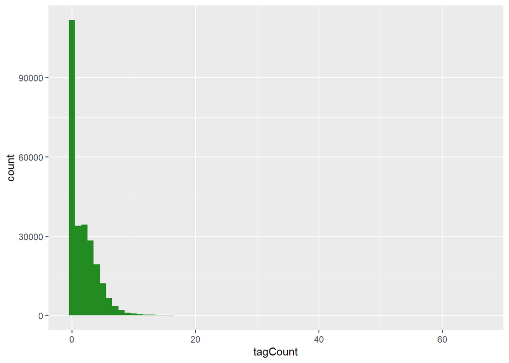

```r
#create histogram for binTFBS
bincts = print(binTFBS)
ggplot(bincts, aes(x = tagCount)) +
  geom_histogram(binwidth = 1, fill = "forestgreen")
```

We can see that there are many zeros in this data. But is the number of zeros significant given the data (look at the frequency of other small numbers)?

We can see that there appears to be many zeros (based on bar height). However, we can’t be sure if the number of zeros is really high because of the small frequencies of many other numbers (1, 2, …).

Let’s look at the log (base10) transformed histogram and estimate the proportion of bins with zero counts.

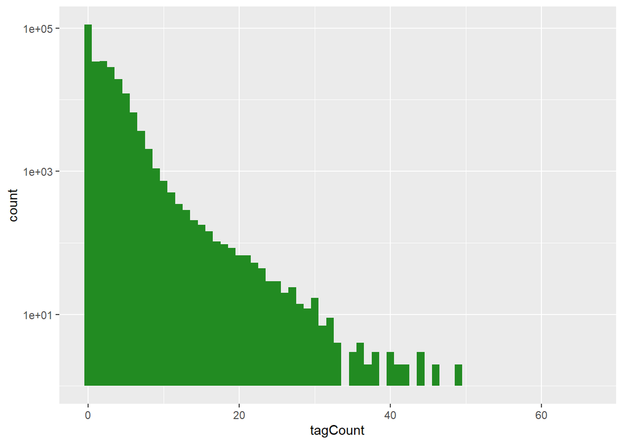

```r
ggplot(bincts, aes(x = tagCount)) + scale_y_log10() +
   geom_histogram(binwidth = 1, fill = "forestgreen")
```

```r
##estimate the proportion of bins with zero counts
```

[output not shown]

Is this a significant number of zeros? The proportion of zeros in the data doesn’t look significant based on the counts of other numbers (is this true - we’re not sure).

**More than two components**<sup>Return</sup>

Let’s look at an example of a mixture model with more than two components. What sort of histogram do we get when when weighing N=7,000 nucleotides obtained from mixtures of deoxyribonucleotide monophosphates (each type has a different weight, measured with the same standard deviation sd=3).

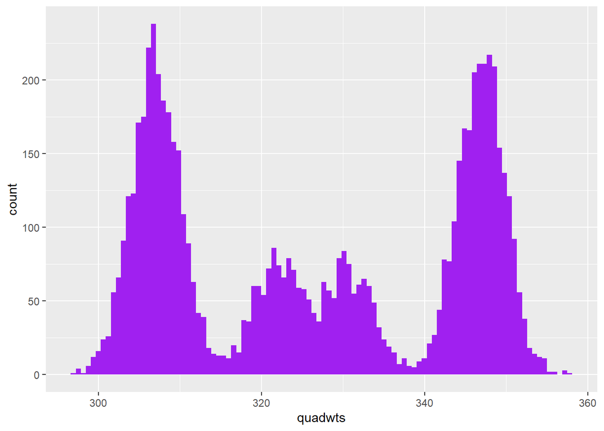

```r
masses = c(A =  331, C =  307, G =  347, T =  322)
probs  = c(A = 0.12, C = 0.38, G = 0.36, T = 0.14)
N  = 7000
sd = 3
set.seed(1234)
nuclt   = sample(length(probs), N, replace = TRUE, prob = probs)
quadwts = rnorm(length(nuclt),
                mean = masses[nuclt],
                sd   = sd)
ggplot(tibble(quadwts = quadwts), aes(x = quadwts)) +
  geom_histogram(bins = 100, fill = "purple")
```

This kind of looks like 4 separate components. What does this distribution look like compared to the theoretical density distribution?

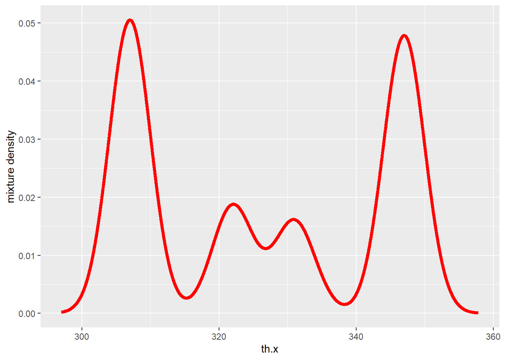

```r
#can generate theoretical distribution but cant get it to code on top

#generate theoretical distribution using code from figure 4.3 as example
th.density = tibble(
  th.x = seq(min(quadwts), max(quadwts), length.out = 7000),
  ds =0.12 * dnorm(th.x, mean = masses[1], sd = 3) +
      0.38 * dnorm(th.x, mean = masses[2], sd = 3) +
      0.36 * dnorm(th.x, mean = masses[3], sd = 3) +
      0.14 * dnorm(th.x, mean = masses[4], sd = 3))
ggplot() +
  geom_line(data=th.density, aes(x = th.x, y = ds),
            color = "red", size = 1.5) +
  ylab("mixture density")
```

What happens if we repeat this exercise with N=1000 nucleotide measurements? (decreasing the #observations)

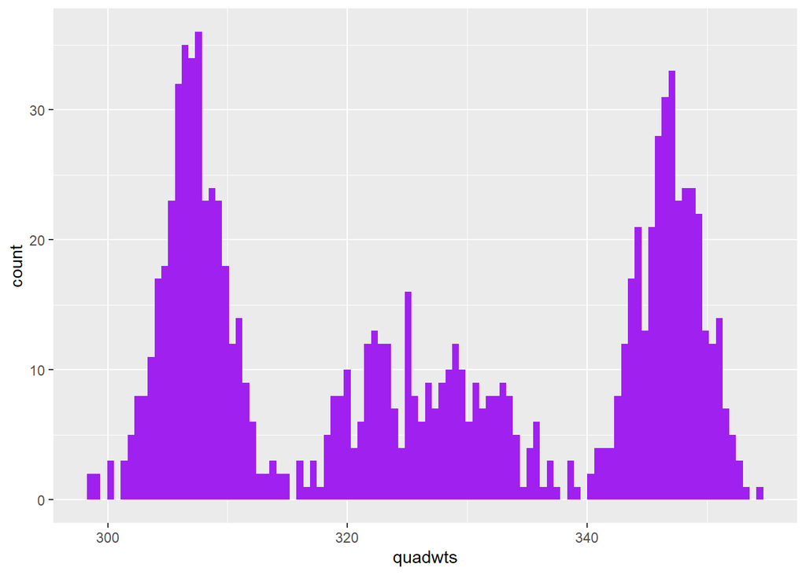

```r
N  = 1000
sd = 3
set.seed(1234)
nuclt   = sample(length(probs), N, replace = TRUE, prob = probs)
quadwts = rnorm(length(nuclt),
                mean = masses[nuclt],
                sd   = sd)
ggplot(tibble(quadwts = quadwts), aes(x = quadwts)) +
  geom_histogram(bins = 100, fill = "purple")
```

The individual components have become less distinct. Now it looks like there are only 3 separate components to this data.

What happens if we keep N=7000 measurements but make the standard deviation 10?

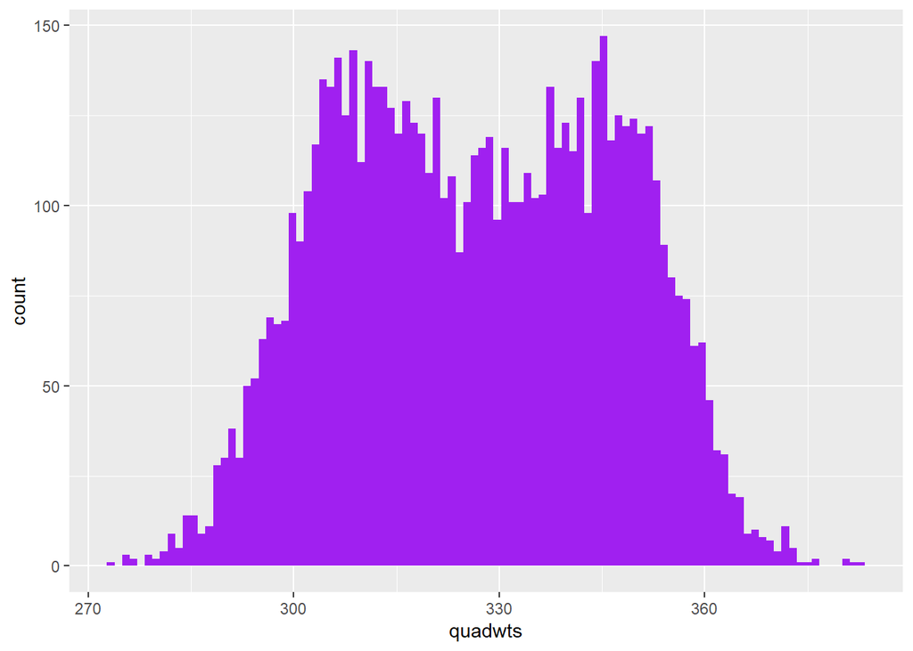

```r
N  = 7000
sd = 10
set.seed(1234)
nuclt   = sample(length(probs), N, replace = TRUE, prob = probs)
quadwts = rnorm(length(nuclt),
                mean = masses[nuclt],
                sd   = sd)
ggplot(tibble(quadwts = quadwts), aes(x = quadwts)) +
  geom_histogram(bins = 100, fill = "purple")
```

Now the individual components are even less distinct. It looks like there are only 2 components within our 4 component data.

- **NOTE** -
  - μ (mean) = any real number, the location parameter
    - Location parameter tells where graph is located (Where on the horizontal axis centers the graph, relative to normal distribution model)
      - ex) normal distribution is centered at 0, so if parameter=5 -> center graph 5 units to right of 0
  - σ = the scale parameter (Only true for normal distribution)
    - Scale parameter used w/ location parameters to determine shape & location of a distribution
    - Scale stretches/squeezes a graph
      - ex) Scale of 3 = stretches curve, scale of 1/3 = narrows curve
        - In other distributions, scale=/= sd
        - Scale rules
          - larger scale parameter = more spread distribution, smaller scale parameter = more compressed distribution
            - Scale paramter = 0 -> single vertical line at 0 (of a normal distribution - the mean)
            - Scale parameter = 0-1 -> horizontal squeeze on distribution
            - Scale parameter = 1 -> no change
            - Scale parameter >1 -> horizontal stretch on distribution

**Empirical distributions and the nonparametric bootstrap**<sup>Return</sup>

This type of data deals with the situation where the number of observations is equal to the number of mixture components.

Let’s use Darwin’s *Zea mays* data where he compared heights of 15 self-hybridized and 15 self-crossed plants as example.

```r
#look at heights of plants
ZeaMays$diff
```

```
##  [1]  6.125 -8.375  1.000  2.000  0.750  2.875  3.500  5.125  1.750  3.625
## [11]  7.000  3.000  9.375  7.500 -6.000
```

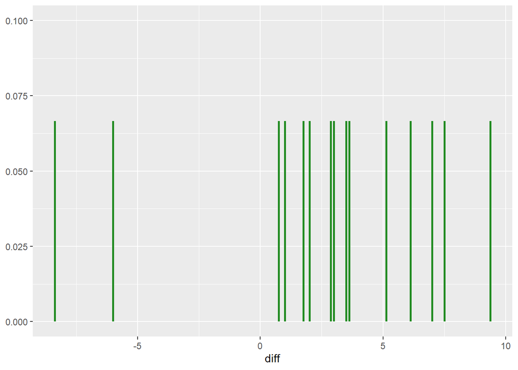

```r
#plot heights of plants
ggplot(ZeaMays, aes(x = diff, ymax = 1/15, ymin = 0)) +
  geom_linerange(size = 1, col = "forestgreen") + ylim(0, 0.1)
```

In general, the density of a probability distribution is the derivative (if it exists) of the empirical cumulative distribution function (ECDF).

Statistics of our sample, such as the mean, minimum or median, can also be written as a function of the ECDF.

The **emperical cumulative distribution function (ECDF)** for sample of size n:

$$\begin{equation}
\hat{F}_n(x)= \frac{1}{n}\sum_{i=1}^n {\mathbb 1}_{x \leq x_i},
\tag{4.4}
\end{equation}$$

ECDF plots allow us to write density of sample as:

$$\begin{equation}
\hat{f}_n(x) =\frac{1}{n}\sum_{i=1}^n \delta_{x_i}(x)
\tag{4.5}
\end{equation}$$

- ECDF is a probability model for emperical data when sampling from a sample instead of the entire population

The true sampling distribution of a statistic ^τ is often hard to know as it requires many different data samples from which to compute the statistic.

*Bootstrapping* is a method to approximate the true sample distribution of ^τ creating new samples drawn from the empirical distribution built from the original sample.

Different samples from F lead to different data, and so to different values of the estimate ^τ: this is called sampling variability. The distribution of all the ^τ’s is the sampling distribution.

We reuse the data (by considering it a mixture distribution of δs) to create new “datasets” by taking samples and looking at the sampling distribution of the statistics ^τ∗ computed on them. This is called the *nonparametric bootstrap approach*.

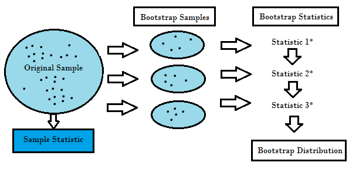

- This is a type of resampling which generates a large number of smaller samples of the same size being repeatedly drawn from original sample (*With replacement*)
  - resamples can have the same observation repeated in a single smaller sample set due to sampling w/ replacement
  - **All the iterations of resampling generates a bootstrap statistic which is compiled into a bootstrap distribution**
  - Bootstrap based on law of large numbers = if you sample over & over then your data should approximate ture population data
- Procedure
  1. Resample dataset x times
  2. Find summary statistic (bootstrap statistic) for each x samples
  3. Estimate sd for bootstrap statistic using sd of bootstrap distribution

Let’s use bootstrapping to estimate the sampling distribution of the median of the Zea Mays differences.

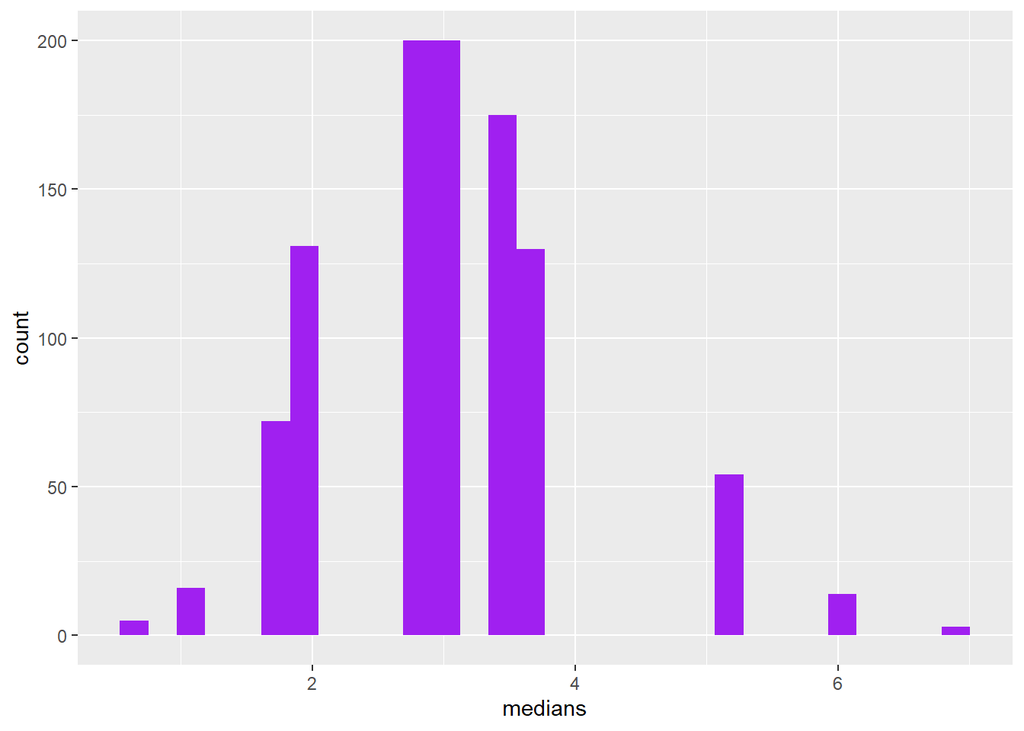

```r
B = 1000
#Use Monte Carlo to draw 1000 samples of size 15 from the 15 values
#compute the 1000 medians of each of these samples of 15 values
set.seed(1234)
meds = replicate(B, {
  i = sample(15, 15, replace = TRUE)
  median(ZeaMays$diff[i])
})
#look at the disribution
ggplot(tibble(medians = meds), aes(x = medians)) +
  geom_histogram(bins = 30, fill = "purple")
```

Estimate a 99% confidence interval for the median based on these simulations. What can you conclude from looking at the overlap between this interval and 0?

```r
# Bootstrap percentile/quantile method
  # 99% CI means 100%-99% = trim 1% off ends of the distribution (0.5% each upper/lower = 0.005)
  # In quantiles this equates to 0.005 quantile (lower) & 1-0.005 = 0.995 (upper)
  # The conclusion = IDK
quantile(meds,c(0.005,0.995))
```

```
##    0.5%   99.5%
## 0.99875 6.12500
```

- Bootstrap Percentile Method
  - Calcualte confidence intervals for bootstrapped samples
  1. Simple method, certain % is trimmed from lower & upper end of the sample statistic (ex) mean or sd)
     - trimmed number depends on confidence interval
     - ex) 90% CI means a 100%-90%=10% trim (trim 5% from upper & lower ends)
     - *Another method -> get 90% CI by taking lower bound 5% & upper bound 95% quantiles* of the B replication T1,T2,…,TB
     - Complicated method -> Bias-corrected & accelerated BCa method

Use the bootstrap package to redo the same analysis using the function bootstrap for both median and mean. What differences do you notice between the sampling distribution of the mean and the median?

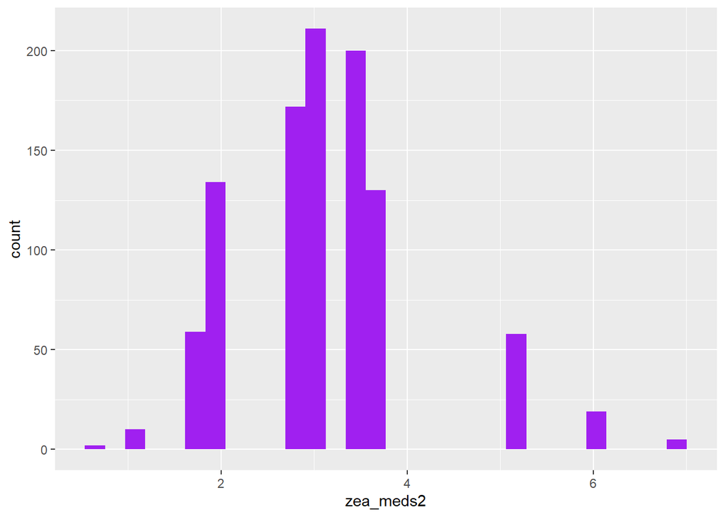

```r
#create a theta function to bootstrap mean
set.seed(1234)
theta <- function(x){
  i = sample(15, 15, replace = TRUE)
  median(ZeaMays$diff[i])
  }

#put bootstrap data into list
zea_meds <- bootstrap(ZeaMays$diff, B, theta)

#plot bootstrap means
ggplot(tibble(zea_meds2=zea_meds$thetastar),aes(x = zea_meds2))+
  geom_histogram(bins = 30, fill = "purple")
```

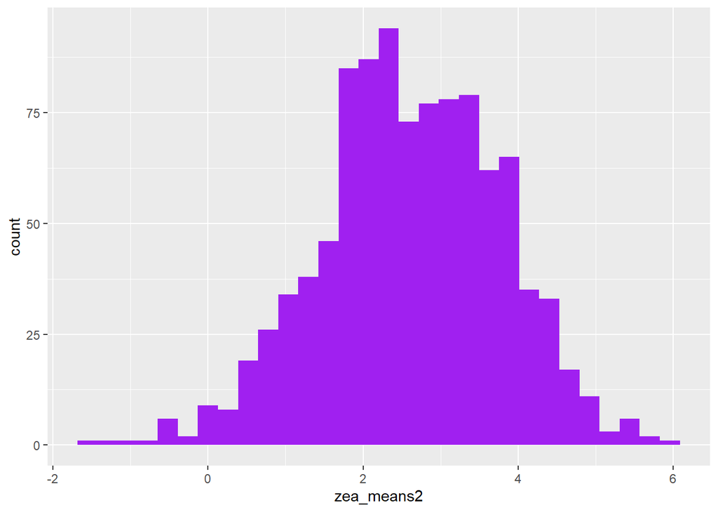

```r
#create a theta function to bootstrap mean
set.seed(1234)
theta <- function(x){
  i = sample(15, 15, replace = TRUE)
  mean(ZeaMays$diff[i])
  }

#put bootstrap data into list
zea_means <- bootstrap(ZeaMays$diff, B, theta)

#plot bootstrap means
ggplot(tibble(zea_means2=zea_means$thetastar),aes(x = zea_means2))+
  geom_histogram(bins = 30, fill = "purple")
```

**Why is this bootstrapping method called nonparametric?**<sup>Return</sup>

Nonparametric methods are those that have infinitely many degrees of freedom or a number of unknown parameters.

A sample does not have to have an infinite number of parameters to be become nonparametic. When the number of parameters becomes as large or larger than the amount of data available, we say the method is nonparametric.

When using nonparametric methods we often replace calculations via simulations (ex. bootstrap) instead of generating all possible samples from emperical distribution. Use Monte Carlo simulation to make bootstrap resamples of data.

- 17. If sample has n=3 different values, how many different bootstrap resamples are possible?
  - Repeat this solution using n=15
- 1. Set of all bootstrap resamples = set of all vectors of n integers (sum is n)
  - Denoted by k=(k1, k2,…,kn) is the #of times the observations (x1, x2,…,xn) occur in a bootstrap sample
    - each k is a box (similar to multinomial distribtuion)
      - n boxes to drop n balls
  - Can count #configurations via counting #of ways separating n balls into boxes
    - ex) write down n times (a ball) & n-1 times (a separator (|)) between them
      - So 2n-1 posiions to fill
        - Must choose either ball or separator
    - If n=3
      - Possible placement would be ball/ball/|/|/ball (5 positions filled by ball/separator)-> k=(2,0,1)
        - n=ball, n-1=separator so 3 balls & 2 separators -> vector of n=3, 2 balls in 1st pos, 1 ball in last
  - In general this number is

$$\begin{equation}
{2n-1} \choose {n-1}
\end{equation}$$

```r
# A) n=3 & n=15 -> nCr
  # 2n-1 when n=3 -> 5 == n total number of positions to be filled
  # k = n = 3 number of samples taken in one iteration
c(N3=choose(n=5,k=3), N15=choose(29,15))
```

```
##       N3      N15
##       10 77558760
```

[figure not shown]

- permutations = ordering of objects -> n!
  - nPr -> out of n objects, how many ways to pick r of n objects **Order is important**
  - nCr -> same as nPr but **Order is not important**
- 17. What are two types of errors that can occur when using the bootstrap method in the `bootstrap` package?
  - What parameter can you change to improve one of the errors?
- 1. Errors
  - Error1: Monte Carlo simulations of subsets of data via random resampling used to approximate exhaustive bootstrap
    - By increasing the size of `nboot` argument of `boostrap()` -> this reduces Monte Carlo error
      - **Keep in mind, exhaustive boostrap is still not exact** b/c using approximate distribution function of data instead of true distribution
  - Error2: If sample size is small or original sample is biased - approximation will be poor
    - Doesn’t matter how large `nboot` is - this can’t resolve the problem
  - `nboot in bootstrap()` is the number of iterations/sampling desired

**Infinite Mixtures**<sup>Return</sup>

If the number of mixture components is as big as (or bigger than) the number of observations, we say we have an infinite mixture.

**Infinite mixture of normals**<sup>Return</sup>

Let’s generate an infinite mixture using 2 levels of data generation.

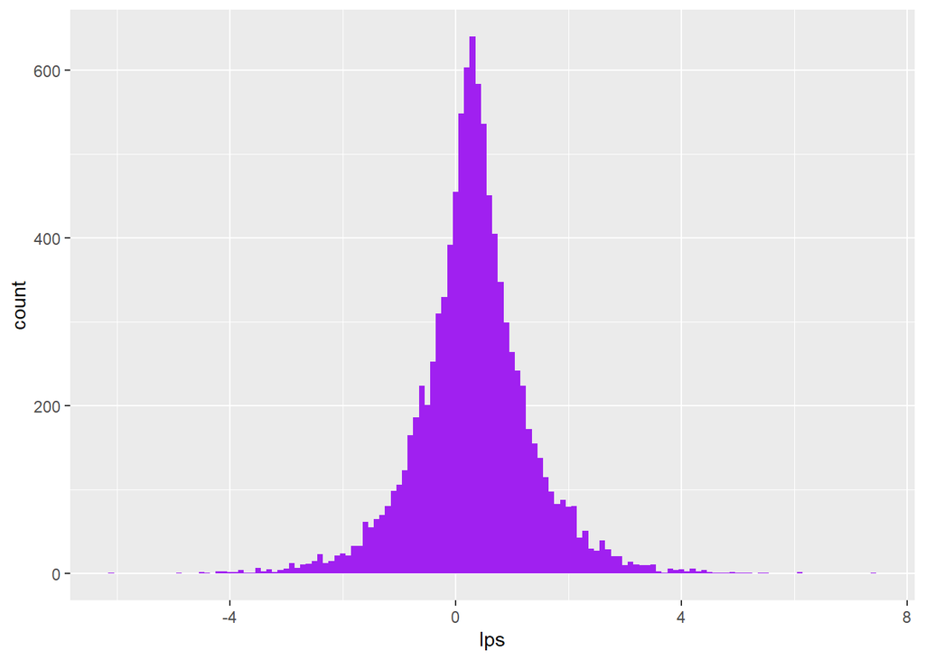

```r
#level 1
#generate 10000 random deviates from the exponential distribution with rate (ie. mean) equal to 1
#Create a sample w from an exponential distribution
w = rexp(10000, rate = 1)

#level 2
#The w vector serves as the variances of normal variables with mean μ (mu) generated using rnorm
mu  = 0.3
lps = rnorm(length(w), mean = mu, sd = sqrt(w))

#plot the data
ggplot(data.frame(lps), aes(x = lps)) +
  geom_histogram(fill = "purple", binwidth = 0.1)
```

This is called a *Laplace distribution* and is useful because **the median is a good estimator of its location parameter θ** and that the **median absolute deviation can be used to estimate its scale parameter ϕ**.

$$\begin{equation}
f_Y(y)=\frac{1}{2\phi}\exp\left(-\frac{|y-\theta|}{\phi}\right),\qquad\phi>0
\end{equation}$$

- Lapace density
  - Knew the above equation (probability density) has median as a location parameter (theta) & median absolute deviation is the scale parameter (Ф)
  - From this formula
    - Level1 (absolute value of difference) Distance has similar position in Laplace density as
    - Level2 (square of difference) in the normal density
- **NOTE** - in Bayesian regression using Laplace distribution as a prior on the coefficients
  - Causes an Level1 penalty -> lasso
  - If Normal distribution as a prior, it will cause a L2 penalty -> ridge regression

**Asymmetric Laplace**<sup>Return</sup>

In the Laplace distribution, the variances of the normal components depend on W, while the means are unaffected. A useful extension adds another parameter θ that controls the locations or centers of the components.

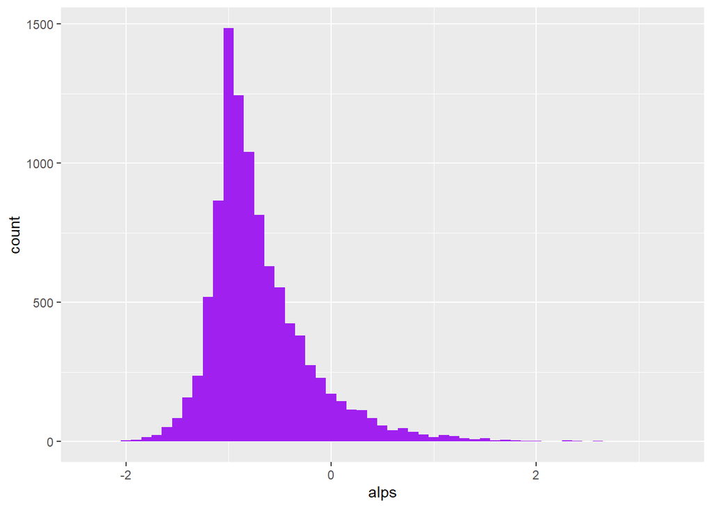

```r
# Make `alps` dataset - use hierarchical model w/ (W) as exponential variable -> varience of normal
  # generate (w) from exponential distribution of mean 1 rexp(rate=1)
  # N(θ+wμ,σw)

mu = 0.3; sigma = 0.4; theta = -1
# Level1
w  = rexp(10000, 1)
# Level2
alps = rnorm(length(w), theta + mu * w, sigma * sqrt(w))

#plot asymmetric laplace
ggplot(tibble(alps), aes(x = alps)) +
  geom_histogram(fill = "purple", binwidth = 0.1)
```

This is a scale mixture of many normal w/ means & variences dependent (X~AL(theta, mu, sigma)). Hierarchical mixture distributions where every instance of the data has its own mean and variance (such as the above), are useful models in many biological settings. The length of promotors in yeast follow an asymmetric laplace distribution.

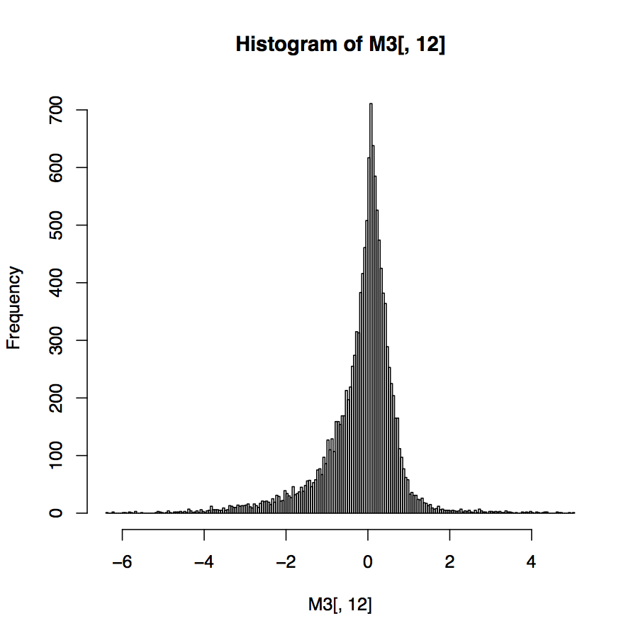

Microarray log-ratio gene expression

The above distribution is generated from the log-ratio of gene expression values from a microarray. How would one explain that the data have a histogram of this form?

Biological interpretation: Most genes have a similar expression to control RNA. More genes are downregulated than upregulated.

The variance of a asymmetric laplace distribution is dependent on its mean (except for when mean=0, such as the case with a symmetric laplace distribution). The mean-variance relationship is common in physical measurements like microarray fluorescence intensity, mass spec peak heights or read counts from next-gen sequencing.

Laplace distribution shows that considering generative process can show how varience & mean are linked - expectation & varience of asymmetic Laplace distribution AL(theta, mu, sigma):

$$\begin{equation}
E(Y) = \theta + \mu \quad\quad\text{and}\quad\quad\text{var}(Y)=\sigma^2+\mu^2.
\tag{4.7}
\end{equation}$$

**Infinite mixtures of poisson variables: the gamma-poisson distribution**<sup>Return</sup>

A two-level heierarchical model is often required to model real-world count data.

For example, supposed we are interested in the variations of fishes in all lakes across Manitoba. We would sample the fish species in each leak to estimate their true abundance. This measurement could be modeled by a Poisson distribution. However, their true abundances will vary from lake to lake. If we were interested in examining if climate plays a role (North vs South), we would have to separate the effect of climate from the random lake to lake variation. Then we can model the Poisson rate parameters (λ) as a distribution of different rates.

Such a hierarchical is advantageous because it allows us to add more steps in if we wish. For example, we could look at many fish species, and model environmental factors separately

The Gamma-Poisson mixture is a two-level hierarchical model. The steps to generating at Gamma-Poisson mixture are as follows: 1. Generate a set of parameters: λ1, λ2,.. from a gamma distribution.

The gamma distribution is an extension of the (one-parameter) exponental distribution. It has two parameters: scale and shape. The two parameters make this distribution more flexible and make it a useful building block in heirarchical models. It is positive valued and continued, and density is at a finite value.

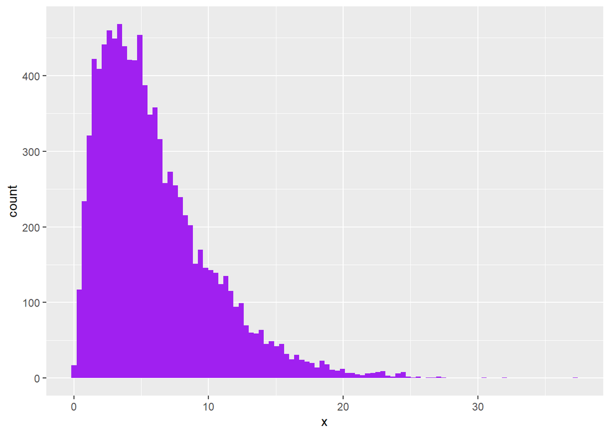

```r
#Let's plot some gamma distributions

#this is a gamma(2,1/3) distribution
ggplot(tibble(x = rgamma(10000, shape = 2, rate = 1/3)),
   aes(x = x)) + geom_histogram(bins = 100, fill= "purple")
```

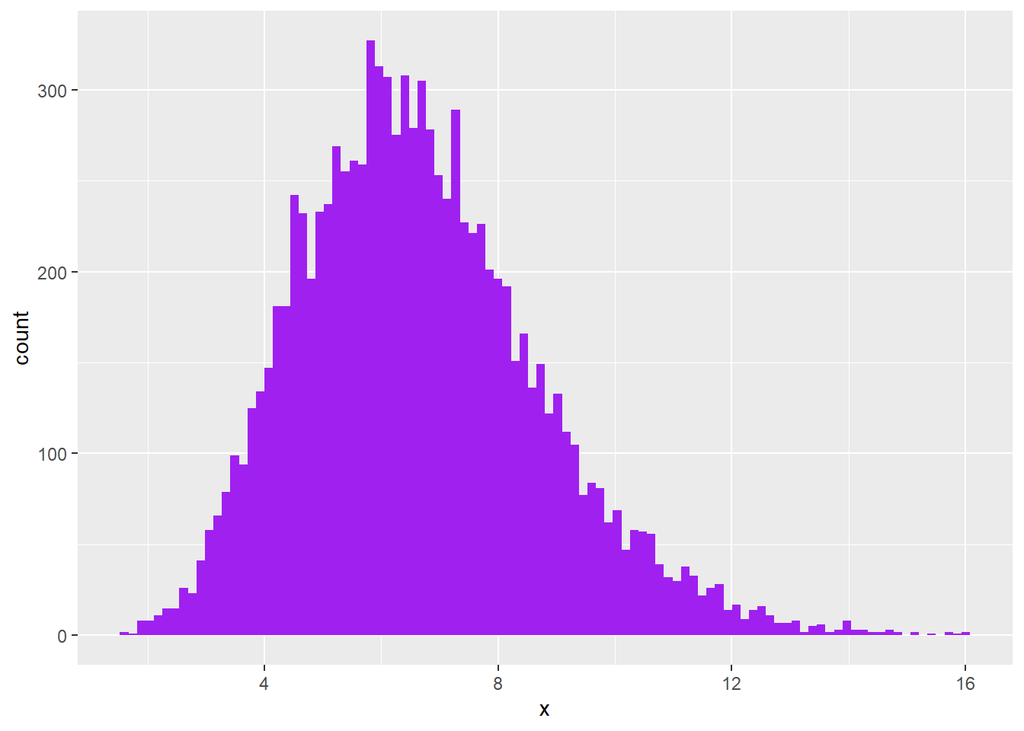

```r
set.seed(1234)
#this is a gamma(10,3/2) distribution
ggplot(tibble(x = rgamma(10000, shape = 10, rate = 3/2)),
   aes(x = x)) + geom_histogram(bins = 100, fill= "purple")
```

Different Poisson rate parameters(lambda) - can be modelled as coming from a distribution of rates

2. Now, let’s take our gamma distribution of (10,3/2) from above and use it to generate a gamma-poisson distribution

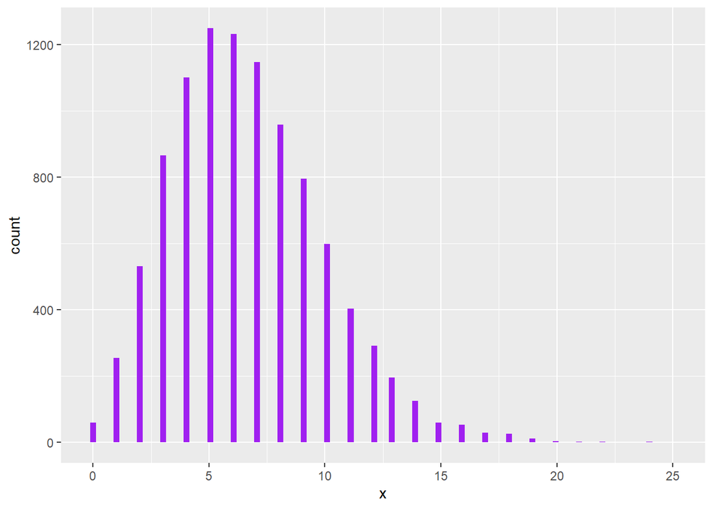

```r
set.seed(1234)
lambda = rgamma(10000, shape = 10, rate = 3/2)
gp = rpois(length(lambda), lambda = lambda)
ggplot(tibble(x = gp), aes(x = x)) +
  geom_histogram(bins = 100, fill= "purple")
```

As we can see, the Gamma-Poisson distribution is a discrete distribution.

Another name for the Gamma-Poisson distribution is the *negative binomial distribution*.

- Formula for equation is similar to binomial distribution
- Gamma-Poisson is more defining of the underlying principles

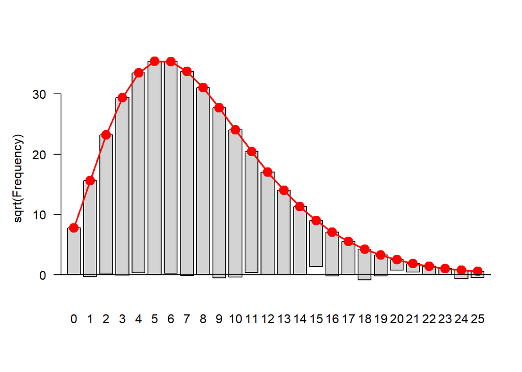

```r
ofit = goodfit(gp, "nbinomial")
plot(ofit, xlab = "")
```

```r
ofit$par
```

```
## $size
## [1] 10.24833
##
## $prob
## [1] 0.6074892
```

**Choosing a data transformation based on a mixture model of your data: variance stabilizing transformations**<sup>Return</sup>

In order to visual whether (and how well) we observe any true differences between our samples/replicates, we must control for the variability in our repeated measure of the same value.

Data that are represented by a hierarchical model typically have heterogenous variances. We can stabilize this sort of variance with a transformation

Let’s look at example of a square root transformation on a series of poisson distributions:

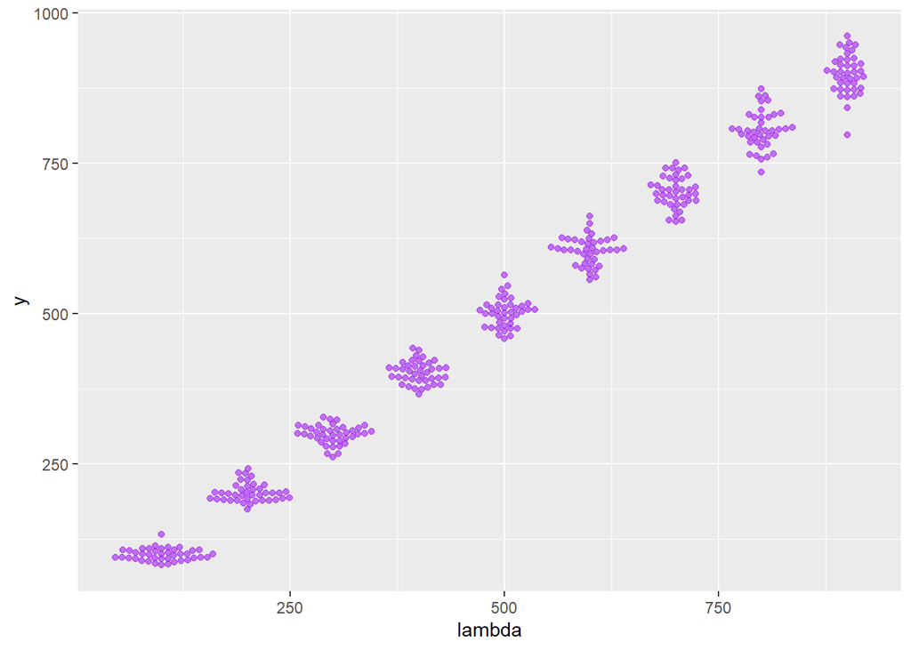

```r
#our lambdas for generation our poisson distributions
set.seed(1234)
lambdas = seq(100, 900, by = 100)


simdat = lapply(lambdas, function(l)
    tibble(y = rpois(n = 40, lambda=l), lambda = l)
  ) %>% bind_rows

#data without transformation
ggplot(simdat, aes(x = lambda, y = y)) +
  geom_beeswarm(alpha = 0.6, color = "purple")
```

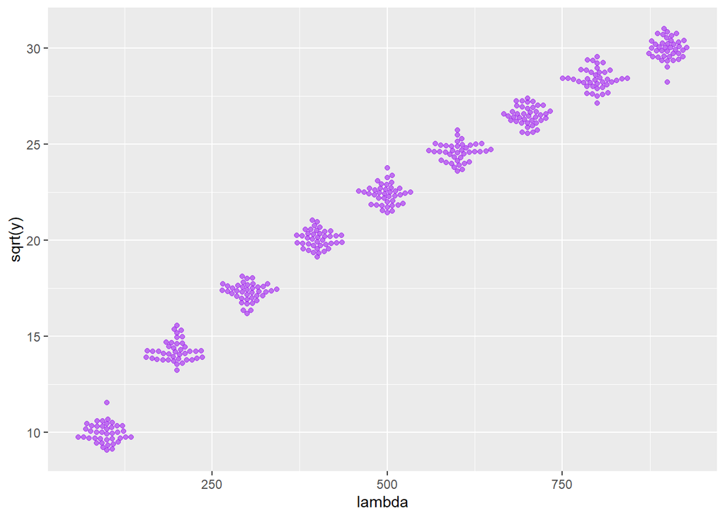

```r
#data with square root transformation
ggplot(simdat, aes(x = lambda, y = sqrt(y))) +
  geom_beeswarm(alpha = 0.6, color = "purple")
```

The graph on the left showsheteroscedasticity: the standard deviations (or, equivalently, the variance) of our data is different in different regions of our data space. In particular, it increases along the x-axis, with the mean.